# R2. Model validation: random-initialization control, extrapolation, noise, model width and KL divergence

This notebook reproduces, from saved result files, every number that the manuscript quotes for

- **Experiment 4, random-initialization control** for the cell type recovery rate (Figure S7),
- **Experiment 8, extrapolation with zero-padding** (Figure S5E and S5F),
- **Experiment 9, noise sensitivity** (Figure S14A and S14B),
- **Experiment 10, latent-dimension sensitivity** (Figure S14C to S14E),
- **Experiment 11, KL-divergence monitoring** (Figure S14F to S14I).

The scripts are in `../codes/`. The cluster commands are shown but not executed. Each number is followed by an `assert`.

[output not shown]

```python
import os, json
import numpy as np
import pandas as pd
from IPython.display import Image, display

R = os.path.join('..', 'results')                           # result files of the revision folder
pct = lambda x: round(100 * float(x), 1)                    # accuracy as a percentage with one decimal

# Figures are drawn by codes/exp24_manuscript_figures.py from the result tables in R
import importlib.util
os.environ['GENESYS_RESULTS'] = os.path.abspath(R)
os.environ['GENESYS_FIGURES'] = os.path.abspath(os.path.join(R, 'figures'))
_spec = importlib.util.spec_from_file_location('figures', os.path.join('..', 'codes', 'exp24_manuscript_figures.py'))
figures = importlib.util.module_from_spec(_spec)
_spec.loader.exec_module(figures)

def load_json(*parts):
    with open(os.path.join(R, *parts)) as fh:
        return json.load(fh)
```

## How the models of this notebook were trained

Every retrained model goes through the training function of the up-to-date GeneSys package, `run_cycle` in `genesys/genesys_cli.py`, called unchanged by `../codes/train_run_cycle.py`: one cycle of 30 epochs with the package defaults (AdamW, learning rate 1e-3, ReduceLROnPlateau with factor 0.5, patience 10 and threshold 0.05, gradient clipping at 5, best weights kept on lowest loss). Whatever an experiment varies enters through the inputs of `run_cycle` only:

- **labels** in the convention of the package, with time starting at 1 (`utils.load_root_data_blueprint`: the stem cells are time 1 and time bins 1 to 10 are times 2 to 11, as in `toy_data/annotations.txt`);
- **lineage blueprint table**: correct, reversed, shuffled or random. The reversed decoy combines the column-reversed table with time-reversed labels. The random table keeps the stem-cell column and draws one of the ten cell types at every later position;
- **model object**: noise level, width, a feedforward network in place of the LSTM, or the TD-VAE loss switched off. For the No TD-VAE ablation `calculate_loss` is replaced by a constant that is not connected to any parameter, so the steps that `run_cycle` assigns to the TD-VAE loss leave the model unchanged;
- **KL logging** is done by wrappers around `model.calculate_loss` and around the validation loader, not by editing the loop.

`../codes/check_blueprint_sequences.py` traces which cells each position of a sequence reads. With these inputs the correct blueprint reads the stem cell and then time bins 1 to 10, the same sequence as the `Root_Dataset` of the original notebooks, and the reversed decoy reads time bins 10 to 1 and then the stem cell.

## 1. Experiment 4: random-initialization control (Figure S7)

`exp25_random_baseline_balanced.py` evaluates the trained model and a randomly initialized model of the identical architecture with the protocol of Figure 3. Test batches are assembled from the lineage blueprint with 200 trajectories for each of the ten cell types (2,000 per batch). For each gene fraction in {0, 0.01, 0.02, 0.05, 0.1, 0.2, 0.5, 1} a random subset of genes is kept and the rest set to zero across all time bins, and the terminal fate is read from the classifier at t10. Ten random gene subsets are evaluated per fraction. Because every cell type contributes the same number of trajectories, a model that always returns one cell type scores exactly 1/10.

The belief-state comparison comes from `exp11_trichoblast_forensics.py`: the belief state of the trained model under an all-zero input is compared, by cosine similarity, with the mean belief state of 200 real cells of each type.

```python
# Commands used on the cluster (not executed here):
#   sbatch --job-name=exp25 experiments/slurm/run_cpu.sh experiments/exp25_random_baseline_balanced.py
#   sbatch --job-name=exp11 experiments/slurm/run_cpu.sh experiments/exp11_trichoblast_forensics.py
```

### 1.2 Recovery rate of the trained and the untrained model

```python
E25 = 'exp25_random_baseline_balanced'
rec = pd.read_csv(os.path.join(R, E25, 'exp25_recovery.csv'))
s25 = load_json(E25, 'exp25_summary.json')
table = rec.groupby(['model', 'fraction'])['accuracy'].agg(['mean', 'std', 'count']).round(4).unstack(0)
print(table.to_string())

assert set(rec.groupby(['model', 'fraction']).size()) == {10}            # ten gene subsets per fraction
rnd = rec[rec['model'] == 'random']
trn = rec[rec['model'] == 'trained']

# untrained model, all genes masked: exactly 0.10 in every evaluation
assert (rnd[rnd['fraction'] == 0]['accuracy'] == 0.1).all()
# untrained model over all gene fractions: mean 0.09, individual evaluations 0.03 to 0.16
print('untrained model: mean', round(rnd['accuracy'].mean(), 2), ', min', round(rnd['accuracy'].min(), 2), ', max', round(rnd['accuracy'].max(), 2))
assert round(rnd['accuracy'].mean(), 2) == 0.09
assert (round(rnd['accuracy'].min(), 2), round(rnd['accuracy'].max(), 2)) == (0.03, 0.16)
# trained model with 10% of the genes
t10 = trn[trn['fraction'] == 0.10]
print('trained model, 10% of genes:', round(t10['accuracy'].mean(), 3), 'with', int(t10['n_genes_kept'].iloc[0]), 'genes')
assert round(t10['accuracy'].mean(), 3) == 0.999 == s25['trained_10pct']
assert int(t10['n_genes_kept'].iloc[0]) == 1751
# trained model with all genes masked also scores 0.10 (it returns one cell type for every trajectory)
assert (trn[trn['fraction'] == 0]['accuracy'] == 0.1).all()
```

```
            mean             std          count
model     random trained  random trained random trained
fraction
0.00      0.1000  0.1000  0.0000  0.0000     10      10
0.01      0.1000  0.1602  0.0002  0.0524     10      10
0.02      0.0988  0.3850  0.0033  0.1051     10      10
0.05      0.1005  0.9494  0.0265  0.0517     10      10
0.10      0.0971  0.9990  0.0354  0.0010     10      10
0.20      0.0876  0.9998  0.0285  0.0003     10      10
0.50      0.0828  0.9998  0.0293  0.0003     10      10
1.00      0.0597  0.9999  0.0044  0.0002     10      10
untrained model: mean 0.09 , min 0.03 , max 0.16
trained model, 10% of genes: 0.999 with 1751 genes
```

### 1.3 The default cell type of an untrained model depends on the initialization

```python
seeds = pd.read_csv(os.path.join(R, E25, 'exp25_seed_scores.csv'))
masked = seeds[seeds['fraction'] == 0]
print(masked.to_string(index=False))

assert len(masked) == 10 and (masked['accuracy'] == 0.1).all() and (masked['dominant_share'] == 1.0).all()
n_types = masked['dominant_class'].nunique()
print('different default cell types over ten seeds:', n_types)
assert n_types == 6
assert 'Trichoblast' not in set(masked['dominant_class'])
```

```
 seed  fraction  accuracy dominant_class  dominant_share
    0       0.0       0.1         Phloem             1.0
    1       0.0       0.1     Endodermis             1.0
    2       0.0       0.1      Pericycle             1.0
    3       0.0       0.1         Cortex             1.0
    4       0.0       0.1     Endodermis             1.0
    5       0.0       0.1      Columella             1.0
    6       0.0       0.1     Procambium             1.0
    7       0.0       0.1      Pericycle             1.0
    8       0.0       0.1     Procambium             1.0
    9       0.0       0.1      Pericycle             1.0
different default cell types over ten seeds: 6
```

### 1.4 The trichoblast default of the trained model

```python
assert s25['trained_zero_input_dominant_class'] == 'Trichoblast' and s25['trained_zero_input_dominant_share'] == 1.0

bel = pd.read_csv(os.path.join(R, 'exp11_trichoblast', 'exp11_trained_belief_distances.csv'))
bel = bel.sort_values('cosine_sim_zero_to_mean_belief', ascending=False)
print(bel[['terminal_cell_type', 'n_cells', 'cosine_sim_zero_to_mean_belief']].round(2).to_string(index=False))

cos = bel.set_index('terminal_cell_type')['cosine_sim_zero_to_mean_belief']
assert round(cos['Trichoblast'], 2) == 0.85 and round(cos['Atrichoblast'], 2) == 0.76
assert cos.drop(['Trichoblast', 'Atrichoblast']).max() < 0.6
```

```
terminal_cell_type  n_cells  cosine_sim_zero_to_mean_belief
       Trichoblast      200                            0.85
      Atrichoblast      200                            0.76
            Cortex      200                            0.59
  Lateral Root Cap      200                            0.45
             Xylem      200                            0.44
         Columella      200                            0.42
        Endodermis      200                            0.42
            Phloem      200                            0.38
        Procambium      200                            0.32
         Pericycle      200                            0.30
```

```
  saved figS_random_baseline.pdf / .png / .tif  (5.92 x 2.82 in at 600 dpi)
```

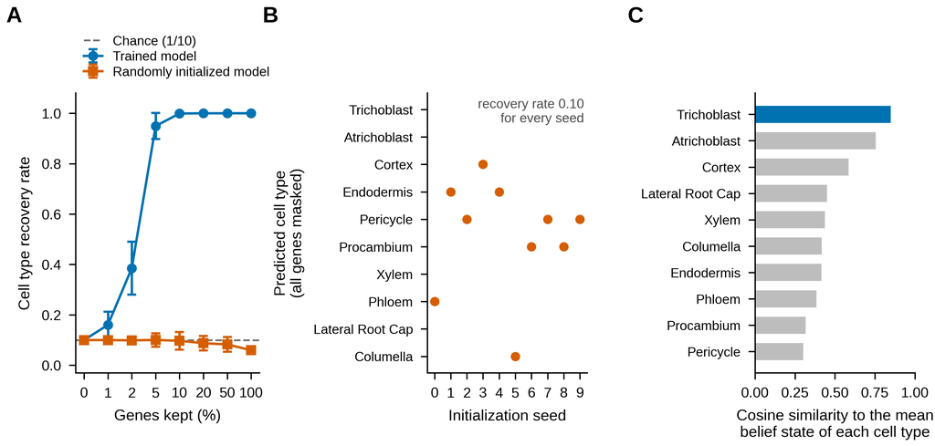

```python
figures.figure_random_baseline()   # Figure S7, drawn from the tables above
display(Image(os.path.join(R, 'figures', 'figS_random_baseline.png'), width=900))
```

## 2. Experiment 8: extrapolation with zero-padding (Figure S5E and S5F)

`exp7_extrapolation.py` uses the published model, with sequences built in the convention described above (stem cell at t0, then time bins 1 to 10). For each seed length *k* in {0, 1, 2, 3, 5, 7, 11} only the first *k* time bins of each input sequence hold real cells and the remaining positions are filled with zeros. Two quantities are recorded at every time bin: the accuracy of the classifier, and the cosine similarity between the transcriptome that the TD-VAE generates for that bin and the real transcriptome. The evaluation uses up to 128 validation cells for each of the ten trajectories, 1,280 sequences per seed length.

```python
# Command used on the cluster (not executed here):
#   python experiments/exp7_extrapolation.py --device cpu        (part of experiments/slurm/post_rc.sh)
```

### 2.2 Accuracy at the zero-filled time bins

```python
ex = pd.read_csv(os.path.join(R, 'exp7_extrapolation.csv'))
assert sorted(ex['seed_bins'].unique()) == [0, 1, 2, 3, 5, 7, 11] and set(ex['n_samples']) == {1280}
print((ex.pivot(index='seed_bins', columns='time_bin', values='accuracy') * 100).round(1).to_string())

unseen = ex[~ex['is_seeded']].groupby('seed_bins')['accuracy'].mean()
print('\nmean accuracy over the zero-filled bins (%):')
print((unseen * 100).round(1).to_string())
assert pct(unseen[7]) == 78.1 and pct(unseen[3]) == 21.5
assert pct(unseen[0]) == 10.0 and pct(unseen[1]) == 10.0          # chance level with 0 or 1 seed bins
```

```
time_bin      0      1      2      3      4      5      6      7      8      9      10
seed_bins
0           10.0   10.0   10.0   10.0   10.0   10.0   10.0   10.0   10.0   10.0   10.0
1           10.0   10.0   10.0   10.0   10.0   10.0   10.0   10.0   10.0   10.0   10.0
2           15.4   29.4   29.5   21.9   13.8   10.1   10.0   10.0   10.0   10.0   10.0
3           40.2   54.3   58.8   53.0   37.7   23.4   17.3   10.5   10.0   10.0   10.1
5           92.9   92.6   93.8   95.4   92.1   78.2   69.8   58.4   43.2   39.5   29.0
7           99.1   99.1   99.5   99.8  100.0   99.7   99.0   80.2   79.9   79.5   72.9
11         100.0  100.0  100.0  100.0  100.0  100.0  100.0  100.0  100.0  100.0  100.0

mean accuracy over the zero-filled bins (%):
seed_bins
0    10.0
1    10.0
2    13.9
3    21.5
5    53.0
7    78.1
```

### 2.3 Cosine similarity between generated and real transcriptomes

```python
cosm = ex.pivot(index='seed_bins', columns='time_bin', values='cosine_similarity').round(2)
print(cosm.to_string())

# With 7 seed bins the similarity is 0.38 to 0.61 across the seeded bins (t0 to t6) and 0.38 at the first zero-filled bin (t7).
assert (cosm.loc[7, 0:6].min(), cosm.loc[7, 0:6].max()) == (0.38, 0.61) and cosm.loc[7, 7] == 0.38
assert cosm.loc[7, 8:10].max() <= 0.21                                  # about 0.2 thereafter
# With 3 seed bins it is 0.37 to 0.49 across the seeded bins (t0 to t2) and 0.21 at the first zero-filled bin (t3).
assert (cosm.loc[3, 0:2].min(), cosm.loc[3, 0:2].max()) == (0.37, 0.49) and cosm.loc[3, 3] == 0.21
# The similarity at the zero-filled bins falls as fewer bins are seeded.
unseen_cos = ex[~ex['is_seeded']].groupby('seed_bins')['cosine_similarity'].mean()
print('\nmean cosine similarity over the zero-filled bins:'); print(unseen_cos.round(2).to_string())
assert unseen_cos[7] > unseen_cos[5] > unseen_cos[3]
```

```
time_bin     0     1     2     3     4     5     6     7     8     9     10
seed_bins
0          0.07  0.08  0.11  0.13  0.15  0.16  0.17  0.18  0.18  0.18  0.19
1          0.44  0.10  0.14  0.15  0.17  0.17  0.18  0.18  0.18  0.19  0.19
2          0.43  0.44  0.16  0.16  0.16  0.17  0.17  0.18  0.18  0.18  0.19
3          0.42  0.49  0.37  0.21  0.17  0.17  0.17  0.18  0.18  0.19  0.19
5          0.38  0.58  0.53  0.51  0.47  0.31  0.19  0.18  0.18  0.19  0.20
7          0.38  0.61  0.57  0.54  0.55  0.53  0.52  0.38  0.21  0.21  0.21
11         0.38  0.62  0.57  0.55  0.56  0.54  0.55  0.55  0.57  0.59  0.61

mean cosine similarity over the zero-filled bins:
seed_bins
0    0.15
1    0.17
2    0.17
3    0.18
5    0.21
7    0.25
```

```
  saved figS5EF_extrapolation.pdf / .png / .tif  (5.90 x 2.15 in at 600 dpi)
```

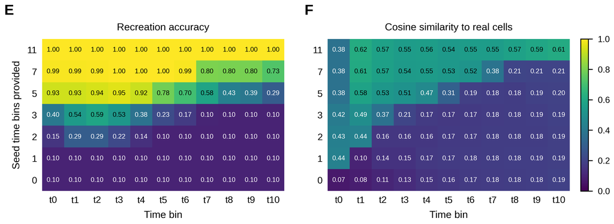

```python
figures.figure_extrapolation_panels()   # Figure S5E and S5F, drawn from the tables above
display(Image(os.path.join(R, 'figures', 'figS5EF_extrapolation.png'), width=900))
```

## 3. Experiment 9: noise sensitivity (Figure S14A and S14B)

Four models are trained through `rescue_train_and_eval.py` and `train_run_cycle.py` that differ in the standard deviation of the Gaussian noise applied to the embedding, 0.0, 0.1, 0.2 (the default) and 0.4. The noise is relative: for each embedding dimension it is drawn with a standard deviation equal to sigma times the absolute value of that dimension, so a zero-valued dimension receives no noise. The models are compared by recreation accuracy and by autoregressive generation accuracy on the validation split. Generation accuracy is set against four runs of the default configuration under the same 30-epoch protocol (the full model of the ablation, the width of 256, the correct blueprint of the decoy experiment and the noise level of 0.2), which shows how much it varies between training runs.

```python
# Commands used on the cluster (not executed here):
#   sbatch --job-name=rc_exp4_<sigma> --gres=gpu:1 experiments/slurm/run_gpu_fast.sh \
#       experiments/rescue_train_and_eval.py --experiment=exp4 --condition=<0.0|0.1|0.2|0.4> --epochs 30
#   python experiments/eval_recreation_accuracy_v2.py --experiment exp4 --condition <sigma> --device cpu
```

```python
sigmas = ['0.0', '0.1', '0.2', '0.4']
noise = pd.Series({s: pct(load_json('exp4_noise', f'sigma_{s}', f'exp4_{s}_recreation_acc_v2.json')['mean_acc']) for s in sigmas},
                  name='recreation accuracy (%)')
print(noise.to_string())
assert (noise.min(), noise.max()) == (82.6, 86.2)             # "all conditions achieve 82.6 to 86.2%"
assert noise.max() - noise.min() < 4                           # "varying by less than four percentage points"
# autoregressive generation of the same four models, and of four runs of the default configuration
gen_noise = pd.Series({s: pct(load_json('exp4_noise', f'sigma_{s}', f'exp4_{s}_recreation_acc.json')['mean_acc']) for s in sigmas},
                      name='generation (%)')
print(gen_noise.to_string())
assert list(gen_noise) == [74.0, 55.8, 66.7, 58.7]             # "ranged from 55.8% to 74.0% ... without a consistent trend"
default_runs = {'ablation, full model': pct(load_json('exp6_ablation', 'full', 'exp6_full_recreation_acc.json')['mean_acc']),
                'width 256': round(100 * pd.read_csv(os.path.join(R, 'exp10_latent_sweep_summary.csv')).set_index('dim').loc[256, 'autoregressive_mean_acc'], 1),
                'decoy, correct blueprint': pct(load_json('exp1_decoy', 'correct', 'exp1_correct_recreation_acc.json')['mean_acc']),
                'noise 0.2': gen_noise['0.2']}
print(default_runs)
assert (min(default_runs.values()), max(default_runs.values())) == (59.6, 66.7)   # "spanned 59.6% to 66.7% for four runs"
```

```
0.0    84.5
0.1    82.6
0.2    86.2
0.4    82.7
0.0    74.0
0.1    55.8
0.2    66.7
0.4    58.7
{'ablation, full model': 59.6, 'width 256': np.float64(61.0), 'decoy, correct blueprint': 61.9, 'noise 0.2': np.float64(66.7)}
```

## 4. Experiment 10: latent-dimension sensitivity (Figure S14C to S14E)

`exp10_latent_sweep.py` trains the model from scratch for 30 epochs (through `train_run_cycle.py`) at four widths, with embedding and hidden dimension 64, 128, 256 and 512. The TD-VAE latent state has twice the embedding width, 128 to 1,024 dimensions. For each width the script records the KL terms at every epoch, the accuracy of the classifier, and the autoregressive generation accuracy.

In this script the column named `recreation_mean_acc` is computed by `evaluate_trained_model` with real cells supplied at every time bin. It is therefore the classification accuracy defined in notebook R1, not the partially seeded recreation accuracy of Figure S5, which is why it is close to 100% here and close to 85% in the other experiments.

```python
# Commands used on the cluster (not executed here), one GPU job per width, then the aggregation:
#   sbatch --job-name=rc_exp10_64 --gres=gpu:1 experiments/slurm/run_gpu_fast.sh experiments/exp10_latent_sweep.py --dim 64 --epochs 30    (and 128, 256, 512)
#   python experiments/exp10_latent_sweep.py --aggregate
```

```python
sw = pd.read_csv(os.path.join(R, 'exp10_latent_sweep_summary.csv')).set_index('dim')
sw['generation (%)'] = (100 * sw['autoregressive_mean_acc']).round(1)
sw['accuracy with real cells at every bin (%)'] = (100 * sw['recreation_mean_acc']).round(2)
# The logged KL(z1) is log q - log p at the sampled latent state with the -eps^2/2 term of log q left out,
# which adds 0.5 nats per latent dimension in expectation; it is removed here, as in Figure S14
sw['KL(z1), offset removed (nats)'] = (sw['final_kl_z1'] - 0.5 * sw['latent_dim']).round(1) + 0.0
print(sw[['latent_dim', 'n_params', 'accuracy with real cells at every bin (%)', 'generation (%)', 'final_kl_z1',
          'KL(z1), offset removed (nats)']].round(1).to_string())

assert list(sw['latent_dim']) == [128, 256, 512, 1024]
assert list(sw['generation (%)']) == [24.4, 37.7, 61.0, 63.6]                     # rises with width and levels off from 256
assert sw['generation (%)'].is_monotonic_increasing and sw.loc[512, 'generation (%)'] - sw.loc[256, 'generation (%)'] < 3
assert (sw['recreation_mean_acc'] > 0.999).all()                                  # insensitive to width
assert [round(v, 1) for v in sw['final_kl_z1']] == [64.0, 130.1, 259.3, 519.6]
assert list(sw['KL(z1), offset removed (nats)']) == [0.0, 2.1, 3.3, 7.6]          # "from 0.0 nats at a width of 64 to 7.6 nats at 512"

kl = pd.read_csv(os.path.join(R, 'exp10_latent_sweep_kl_logs.csv'))
assert set(kl.groupby('dim')['epoch'].nunique()) == {30}                          # 30 epochs at every width
print('\nKL(z1) over the 30 epochs, minimum and maximum per width:')
print(kl.groupby('dim')['kl_z1'].agg(['min', 'max']).round(1).to_string())
```

```
     latent_dim  n_params  accuracy with real cells at every bin (%)  generation (%)  final_kl_z1  KL(z1), offset removed (nats)
dim
64          128   2571187                                      100.0            24.4         64.0                            0.0
128         256   5739251                                      100.0            37.7        130.1                            2.1
256         512  13918579                                      100.0            61.0        259.3                            3.3
512        1024  37650035                                      100.0            63.6        519.6                            7.6

KL(z1) over the 30 epochs, minimum and maximum per width:
       min    max
dim
64    63.6   64.7
128  128.1  130.2
256  255.5  261.8
512  513.2  523.4
```

## 5. Experiment 11: KL-divergence monitoring (Figure S14F to S14I)

`exp3_kl_divergence_from_scratch.py` trains one model from scratch for 30 epochs (through `train_run_cycle.py`) and logs, on the training and the validation split, the four loss components at each epoch: KL(z1) between the inference posterior and the belief prior, KL(z2) between the belief-derived state and the transition prior, the reconstruction loss (binary cross-entropy) and the classifier loss.

```python
# Command used on the cluster (not executed here):
#   sbatch --job-name=rc_exp3 --gres=gpu:1 experiments/slurm/run_gpu_fast.sh experiments/exp3_kl_divergence_from_scratch.py --epochs 30
```

```python
kld = pd.read_csv(os.path.join(R, 'exp3_kl_divergence_diagnostic.csv'))
assert len(kld) == 30
print(kld[['epoch', 'train_kl_z1', 'val_kl_z1', 'train_kl_z2', 'val_kl_z2', 'train_recon', 'train_nll']].iloc[[0, 1, 9, 19, 29]].round(2).to_string(index=False))

# KL(z1) with the offset of 0.5 nats per latent dimension (512 dimensions, 256 nats) removed
kl1 = kld[['train_kl_z1', 'val_kl_z1']] - 0.5 * 512
print('\nKL(z1), offset removed: minimum', kl1.min().round(1).to_dict(), '; epoch 30', kl1.iloc[-1].round(1).to_dict())
assert (kl1 > 0).all().all()                                                     # "stayed above zero throughout training"
assert kl1.iloc[-1].round(1).to_dict() == {'train_kl_z1': 2.2, 'val_kl_z1': 4.7}   # "2.2 nats on the training data and 4.7 nats on the validation data"
```

```
 epoch  train_kl_z1  val_kl_z1  train_kl_z2  val_kl_z2  train_recon  train_nll
     0       280.78     256.33        31.16       2.09      2860.06       2.25
     1       256.65     256.29         1.31       1.26      2031.61       0.77
     9       258.36     257.58         4.78       3.69      1887.74       0.00
    19       258.50     258.85         3.61       6.18      1749.11       0.00
    29       258.20     260.70         4.20       6.84      1707.89       0.00

KL(z1), offset removed: minimum {'train_kl_z1': 0.4, 'val_kl_z1': 0.3} ; epoch 30 {'train_kl_z1': 2.2, 'val_kl_z1': 4.7}
```

```
  saved figS_model_sensitivity.pdf / .png / .tif  (5.92 x 5.93 in at 600 dpi)
```

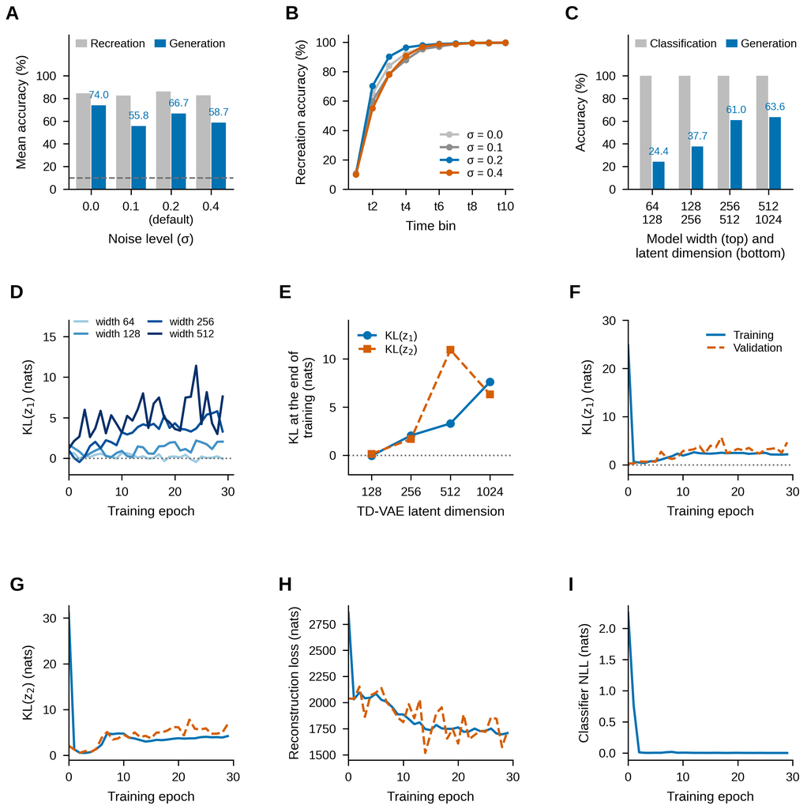

```python
figures.figure_model_sensitivity()   # Figure S14, drawn from the tables above
display(Image(os.path.join(R, 'figures', 'figS_model_sensitivity.png'), width=900))
```